# Takehome Final Exam

## Part C: Comparing Book Ratings before and after Y2K [6 Points]

Is the mean average book score higher for books published before the new millennium, or after the new millennium? Use a formal hypothesis test to support your answer.

```r
post <- books_df |>
  filter(original_publication_year >= 2000) |>
  dplyr::select(average_rating) |>
  unlist()

pre <- books_df |>
  filter(original_publication_year < 2000) |>
  dplyr::select(average_rating) |>
  unlist()

# Null hypothesis: The means are not different in average rating between books published before 2000 and in 2000 and after. Alternative hypothesis: The means are different.

t.test(pre,post)
```

```
##
##  Welch Two Sample t-test
##
## data:  pre and post
## t = 7.4843, df = 8507.1, p-value = 7.909e-14
## alternative hypothesis: true difference in means is not equal to 0
## 95 percent confidence interval:
##  0.02847995 0.04869240
## sample estimates:
## mean of x mean of y
##  4.020769  3.982182
```

```r
# Very small p-value tells us to reject the null hypothesis, and conclude that the means are indeed different.
```

Moreover, does the full distribution (not just the mean) of average book ratings differ between those books released on or before the year 2000 versus those published after the year 2000? For this part, conduct a formal hypothesis test and provide p-value to support your claim.

```r
# Null hypothesis: The distributions are not different in average rating between books published before 2000 and in 2000 and after. Alternative hypothesis: The distributions are different.

ks.test(pre, post)
```

```
##
##  Asymptotic two-sample Kolmogorov-Smirnov test
##
## data:  pre and post
## D = 0.075428, p-value = 3.757e-11
## alternative hypothesis: two-sided
```

```r
# Very small p-value tells us to reject the null hypothesis, and conclude that the distributions are indeed different.
```

## Part D: Test Train Split [2 Points]

Perform a test-train split of the augmented dataset created in Part B such that 90 percent of the data is included in the training set.

```r
library(tidymodels)
set.seed(12345)
books_split <- initial_split(books_df,
                              prop = 0.9)

books_train <- books_split |>
  training()

books_test <- books_split |>
  testing()
```

## Part E: Fitting a Regression Model [8 points]

Using the tidymodels framework, fit a Lasso regression model to the training data with a penalty term valued at 0.0002. Use average_rating as the response variable, and the following covariates:

- num_words
- num_vowels
- num_consonants
- num_digits
- num_good
- num_bad
- language_code
- a natural spline around publication year with 4 degrees of freedom.

Impute any missing data using 5-nearest neighbors. For the language_code factor, create an “other” category for any languages that make up less 0.5 percent of the data. Normalize all the numeric predictors before fitting your model. Hint: remember to that the step_dummy() for the language code variable should occur after the imputation and other category steps.

```r
fit_glmnet <- linear_reg(penalty = 0.0002) |>
  set_engine("glmnet") |>
  set_mode("regression")

recipe_books <- recipe(data = books_train,
                      formula = average_rating ~ num_words + num_vowels + num_consonants + num_digits + num_good + num_bad + language_code + original_publication_year) |>
  step_impute_knn(all_predictors()) |>
  step_ns(original_publication_year, deg_free = 4)

recipe_books <- recipe_books |>
  step_other(language_code,
             threshold = 0.005,
             other = "other") |>
  step_dummy(all_nominal_predictors()) |>
    step_normalize(all_predictors())
```

Display a tidy table showing the estimated regression coefficients.

```r
recipe_workflow_glm <- workflow()

recipe_workflow_glm <- recipe_workflow_glm |>
  add_model(fit_glmnet) |>
  add_recipe(recipe_books)

fit_glm <- recipe_workflow_glm |>
  fit(books_train)

fit_glm |>
  tidy()
```

```
## # A tibble: 15 × 3
##    term                             estimate penalty
##    <chr>                               <dbl>   <dbl>
##  1 (Intercept)                     4.00       0.0002
##  2 num_words                       0.0118     0.0002
##  3 num_vowels                     -0.0272     0.0002
##  4 num_consonants                  0.0342     0.0002
##  5 num_digits                      0.00914    0.0002
##  6 num_good                       -0.000952   0.0002
##  7 num_bad                        -0.000763   0.0002
##  8 original_publication_year_ns_1  0          0.0002
##  9 original_publication_year_ns_2  0.0111     0.0002
## 10 original_publication_year_ns_3 -0.0399     0.0002
## 11 original_publication_year_ns_4  0.0325     0.0002
## 12 language_code_en.GB            -0.00141    0.0002
## 13 language_code_en.US             0.00182    0.0002
## 14 language_code_eng               0.00586    0.0002
## 15 language_code_other             0.0000162  0.0002
```

## Part F: Assessing Performance on Test set [6 Points]

Use the fitted model from Part E to compute predictions for each of the books in the test set.

```r
test_predictions <- fit_glm |>
  predict(books_test)

test_predictions |>
  glimpse()
```

```
## Rows: 914
## Columns: 1
## $ .pred <dbl> 4.003156, 3.968102, 4.041058, 4.009763, 3.951617, 4.028807, 3.96…
```

Which book in the test set has the highest predicted rating?

```r
books_test_pred <- books_test |>
  bind_cols(test_predictions)

books_test_pred |>
  arrange(desc(.pred)) |>
  head(1)
```

```
##                                                                                           book_title
## 1 Band of Brothers: E Company, 506th Regiment, 101st Airborne from Normandy to Hitler's Eagle's Nest
##   language_code original_publication_year average_rating num_words num_vowels
## 1           eng                      1992           4.42        15         24
##   num_consonants num_digits num_good num_bad new_millenium    .pred
## 1             49          6        0       0         FALSE 4.219143
```

```r
# Band of Brothers: E Company, 506th Regiment, 101st Airborne from Normandy to Hitler's Eagle's Nest
```

Create a scatterplot of the true values versus the predicted values. Color the points according to whether or not the book was published before the new millennium.

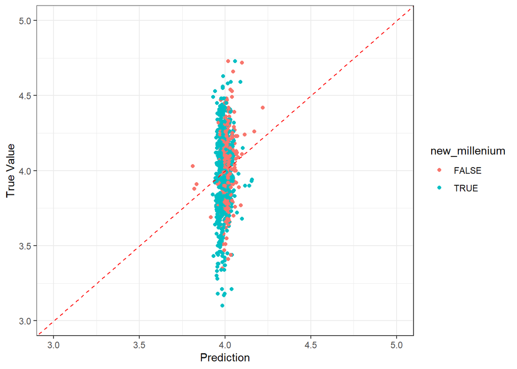

```r
books_test_pred |>
  ggplot(aes(x = .pred, y = average_rating, color = new_millenium)) +
  geom_point() +
  geom_abline(linetype = "dashed", color = "red") +
  xlim(3, 5) +
  ylim(3, 5) +
  labs(x = "Prediction", y = "True Value")
```

Does the model seem like a good fit to you?

It does not. It seems visually to only predict in a narow window very close to 4, when the actual ratings are much more spread out.

Compute the root mean squared error of the fitted model on the test set.

```r
sqrt(mean((books_test_pred$average_rating - books_test_pred$.pred)^2))
```

```
## [1] 0.2623673
```

```r
#0.262
```

## Part G: Bootstrap [6 Points]

Fit the model described in Part E to the 50 bootstrap samples of the original dataset. Use the bootstrap to construct confidence intervals for all of the regression coefficients. Feel free to use the percentile interval method or t interval method (see Homework 11 if this sounds new to you). Which of the regression coefficients appear to be significantly different from zero?

```r
set.seed(11)

control_fit <- control_resamples(extract = tidy)

books_bootstrap <- bootstraps(books_df,
                             times = 50)

bootstrap_fits <-  recipe_workflow_glm |>
  fit_resamples(books_bootstrap,
                control = control_fit)

bootstrap_coefs <- bootstrap_fits  |>
  select(id, .extracts) |>
  unnest(.extracts) |>
  unnest(.extracts)

bootstrap_coefs |>
  glimpse()
```

```
## Rows: 743
## Columns: 5
## $ id       <chr> "Bootstrap01", "Bootstrap01", "Bootstrap01", "Bootstrap01", "…
## $ term     <chr> "(Intercept)", "num_words", "num_vowels", "num_consonants", "…
## $ estimate <dbl> 3.9962322171, 0.0134879150, -0.0241335751, 0.0335299778, 0.00…
## $ penalty  <dbl> 2e-04, 2e-04, 2e-04, 2e-04, 2e-04, 2e-04, 2e-04, 2e-04, 2e-04…
## $ .config  <chr> "Preprocessor1_Model1", "Preprocessor1_Model1", "Preprocessor…
```

```r
bootstrap_std <- bootstrap_coefs |>
  summarize(std.error = sd(estimate),
            estimate = mean(estimate),
            .by = term)

bootstrap_std
```

```
## # A tibble: 15 × 3
##    term                           std.error  estimate
##    <chr>                              <dbl>     <dbl>
##  1 (Intercept)                      0.00261  4.00
##  2 num_words                        0.00783  0.0133
##  3 num_vowels                       0.00790 -0.0274
##  4 num_consonants                   0.00941  0.0336
##  5 num_digits                       0.00259  0.00920
##  6 num_good                         0.00259 -0.00239
##  7 num_bad                          0.00298 -0.000109
##  8 original_publication_year_ns_1   0.00994  0.00262
##  9 original_publication_year_ns_2   0.00638  0.00748
## 10 original_publication_year_ns_3   0.0129  -0.0344
## 11 original_publication_year_ns_4   0.00743  0.0324
## 12 language_code_en.US              0.00899  0.00642
## 13 language_code_eng                0.0103   0.0109
## 14 language_code_other              0.00361  0.000170
## 15 language_code_en.GB              0.00322  0.00211
```

```r
# Intercept, num_vowels, num_consonants, num_digits, original_publication_year_ns_3, original_publication_year_ns_4
```

Make a plot demonstrating the confidence intervals for all coefficients other than the intercept. It may resemble the following, but will likely differ somewhat based on random seeds.

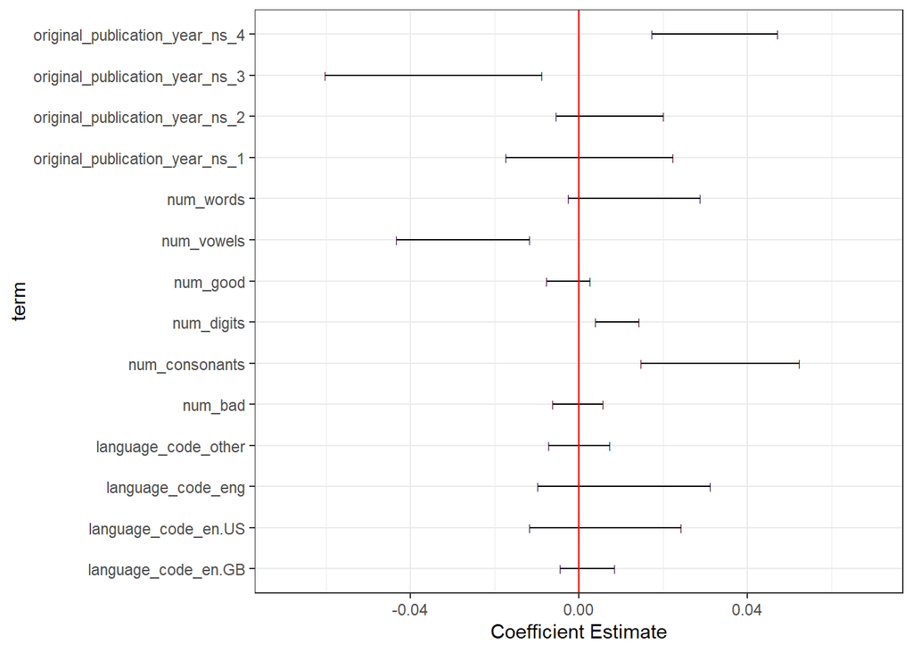

```r
bootstrap_std |>
  filter(term != "(Intercept)") |>
  ggplot(aes(y = term,
             x = estimate)) +
  geom_segment(aes(x = estimate - 2 * std.error,
                   xend = estimate + 2 * std.error,
                   yend = term)) +
  geom_point(aes(x = estimate - 2  * std.error),
             shape = "|") +
  geom_point(aes(x = estimate + 2  * std.error),
             shape = "|") +
  xlim(-0.07, 0.07) +
  geom_vline(xintercept = 0, color = "red") +
  labs(x = "Coefficient Estimate")
```

# Problem 3: [32 Points Total]

Each observation (row) in typingdata.csv is a record of an individual typing the password “.tie5Roanl”. The data was collected across 8 typing sessions for each subject. Each session involved typing the password 50 times. Detailed timing of each keystroke was recorded.

The remaining 31 columns in the data present the timing information for the password.

- Column names of the form H.key designate how long the named key was held down.
- Column names of the form DD.key1.key2 designate the time from when key1 was pressed to when key2 was pressed.
- Column names of the form UD.key1.key2 designate the time from when key1 was released to when key2 was pressed.

Note that UD times can be negative, and that H times and UD times add up to DD times.

```r
# YOUR SOLUTION HERE
```

## Part A: Read in Data [4 Points]

Read in the data. Convert subjectID and sessionIndex to factors. The new data frame should be named `typing`.

```r
typing <- read.csv("typing_data.csv")

typing <- typing |>
  mutate(subject = as.factor(subject)) |>
  mutate(sessionIndex = as.factor(sessionIndex))
```

Recreate the following scatterplot showing the relationship between H.period and H.t across individuals and sessions.

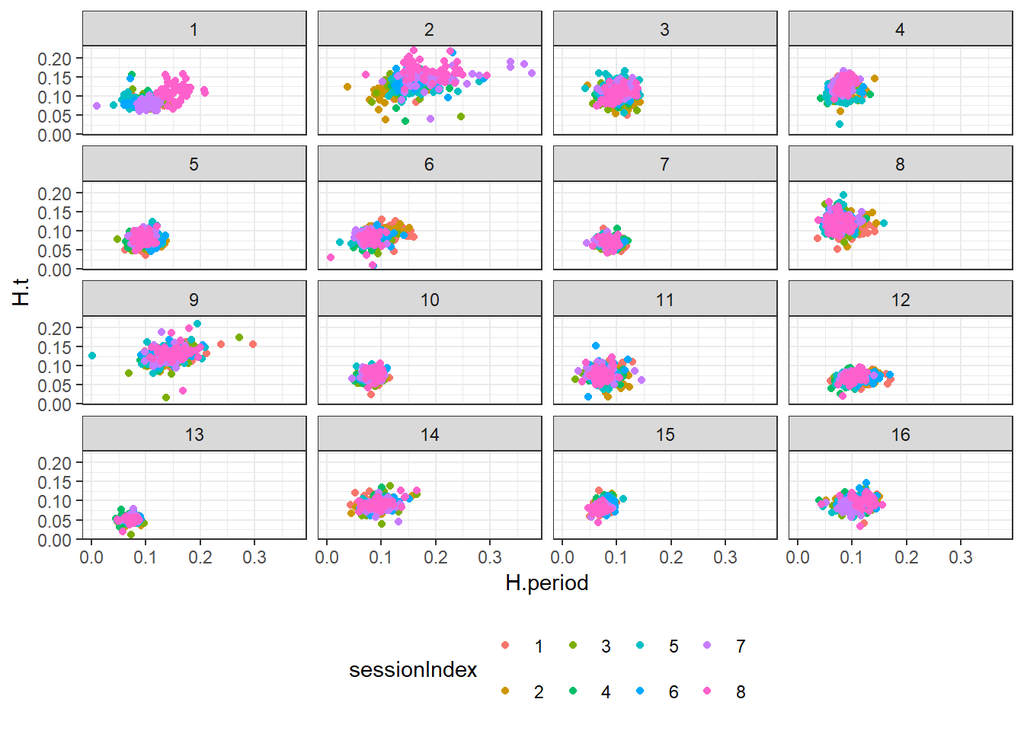

```r
typing |>
  ggplot(aes(x = H.period, y = H.t, color = sessionIndex)) +
  geom_point() +
  facet_wrap(~ subject) +
  theme(legend.position = "bottom")
```

## Part B: Total typing time for each individual [6 Points]

The total time spent typing the password for each trial is defined as the sum of all the of the DD.key1.key2 variables. Add such a new column called total_time to `typing` that represents this information. Note: there are lots of different ways to go about doing this. I will accept any of them. It does not have to be elegant.

```r
typing <- typing |>
  mutate(total_time = DD.period.t + DD.t.i + DD.i.e + DD.e.five + DD.five.Shift.r + DD.Shift.r.o + DD.o.a + DD.a.n + DD.n.l + DD.l.Return)
```

Once you have created the column total_time, create the following plot showing how the total typing time for Subject 2 changed across sessions and repetitions.

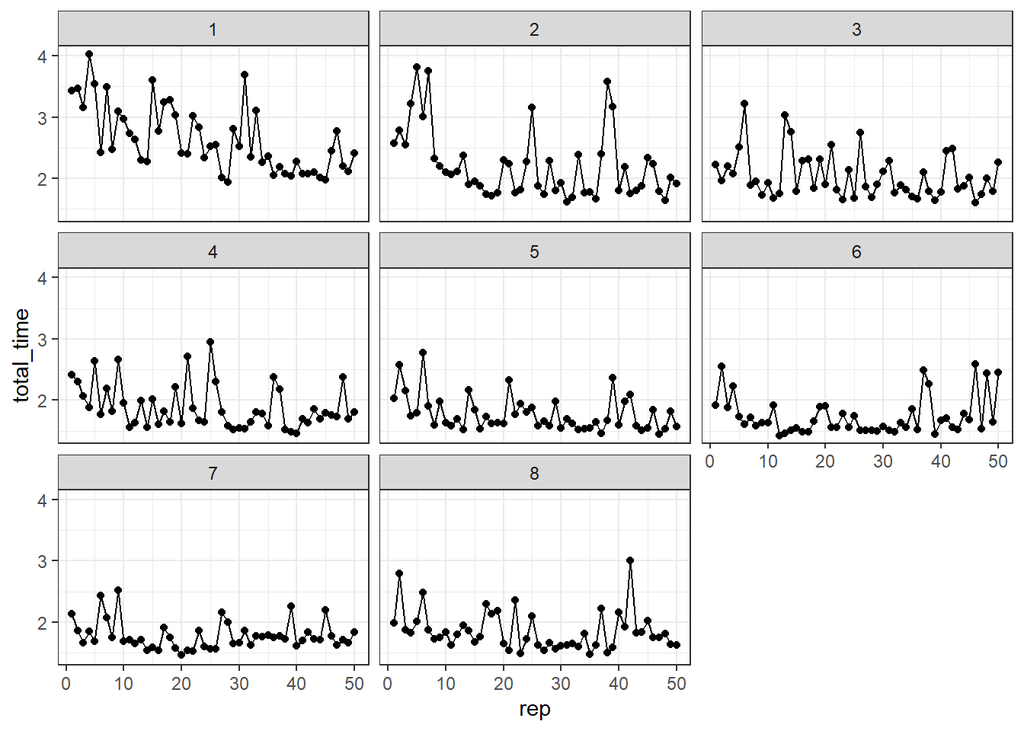

```r
typing |>
  filter(subject == 2) |>
  ggplot(aes(x = rep, y = total_time)) +
  geom_point() +
  geom_line() +
  facet_wrap(~ sessionIndex)
```

## Part C: Average Typing Times [2 Points]

Calculate an average total typing time for each session of each individual. Which individual had the slowest individual session? Which session was it?

```r
typing |>
  group_by(sessionIndex, subject) |>
  summarise(avg_time = mean(total_time)) |>
  arrange(desc(avg_time)) |>
  head(1)
```

```
## # A tibble: 1 × 3
## # Groups:   sessionIndex [1]
##   sessionIndex subject avg_time
##   <fct>        <fct>      <dbl>
## 1 3            12          4.90
```

```r
# Session 3, Subject 12
```

## Part D: Creating Classification Data [4 Points]

Our final task is to build a classifier to distinguish subject 3’s typing patterns from those of the remaining users.

Start by creating an new data frame called typing_classification based on the `typing` data frame we created in Part A. typing_classification should not include the subject, sessionIndex, or total_time columns from typing.

Instead, it should contain a new column called y. y will be a factor taking on the value 1 if subject 3 is the typist, 0 otherwise.

```r
typing_classification <- typing |>
  mutate(y = ifelse(subject == "3", 1, 0)) |>
  mutate(y = as.factor(y)) |>
  dplyr::select(-subject) |>
  dplyr::select(-sessionIndex) |>
  dplyr::select(-total_time)
```

Once the new data frame typing_classification is created, perform a test-train split such that 75 percent of the data is used for training. Make sure to stratify on the y variable in your split.

```r
typing_class_split <- typing_classification |>
  initial_split(prop = 0.75,
                strata = y)

typing_train <- typing_class_split |>
  training()

typing_test <- typing_class_split |>
  testing()
```

## Part F: K-nearest Neighbor Classification [10 Points]

Fit a K-nearest neighbors classifier for y. Use 10-fold cross validation on the training data to choose an optimal value for the number of neighbors, considering the following number of neighbors (1, 10, 20, 30, 40, …, 200). Use roc_auc as your performance metric. Ensure to normalize all the predictors in your model.

```r
library(kknn)
typing_parsnip_knn <- nearest_neighbor(neighbors = tune("neighbors")) |>
  set_engine("kknn") |>
  set_mode("classification")

workflow_typing <- workflow() |>
  add_model(typing_parsnip_knn) |>
  add_formula(y ~ .) |>
  step_normalize(all_predictors())
```

```r
neighbor_grid <- crossing(neighbors = c(1, seq(10, 200, by = 10)))

set.seed(1)
comparison_split <- typing_train |>
  mc_cv(times = 10)

metrics <- metric_set(yardstick::roc_auc)
```

```r
tuning <- workflow_typing  |>
  tune_grid(
    resamples = comparison_split,
    metrics = metrics,
    grid = neighbor_grid
  )
```

```r
tuning |>
  collect_metrics()
```

```
## # A tibble: 21 × 7
##    neighbors .metric .estimator  mean     n  std_err .config
##        <dbl> <chr>   <chr>      <dbl> <int>    <dbl> <chr>
##  1         1 roc_auc binary     0.935    10 0.00319  Preprocessor1_Model01
##  2        10 roc_auc binary     0.983    10 0.00345  Preprocessor1_Model02
##  3        20 roc_auc binary     0.989    10 0.00185  Preprocessor1_Model03
##  4        30 roc_auc binary     0.990    10 0.00177  Preprocessor1_Model04
##  5        40 roc_auc binary     0.991    10 0.00164  Preprocessor1_Model05
##  6        50 roc_auc binary     0.991    10 0.00123  Preprocessor1_Model06
##  7        60 roc_auc binary     0.992    10 0.000880 Preprocessor1_Model07
##  8        70 roc_auc binary     0.991    10 0.000876 Preprocessor1_Model08
##  9        80 roc_auc binary     0.991    10 0.000874 Preprocessor1_Model09
## 10        90 roc_auc binary     0.991    10 0.000895 Preprocessor1_Model10
## # ℹ 11 more rows
```

Create the following plot, showing the relationship between number of neighbors and the mean performance metric across folds. Color and shapte the hyperparameter value(s) that show maximum performance. Note, since you are likely using a different seed, your performance may differ slightly from mine.

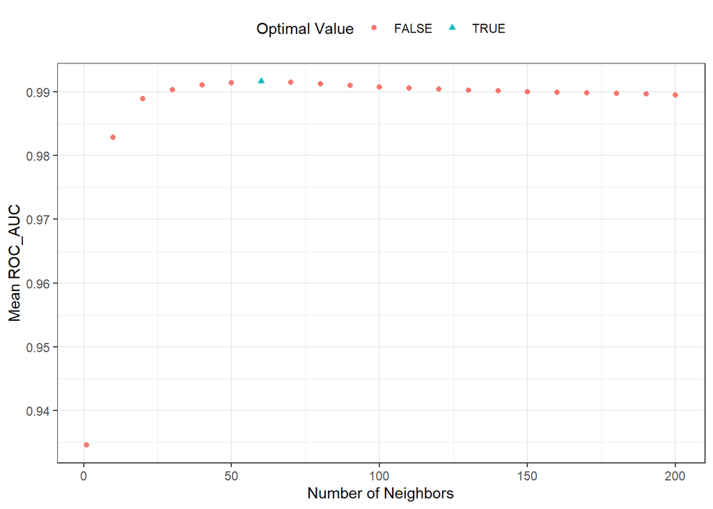

```r
tuning |>
  collect_metrics() |>
  mutate(top = ifelse(neighbors == 60, TRUE, FALSE)) |>
  mutate(top = as.factor(top)) |>
  ggplot(aes(x = neighbors,
             y = mean,
             color = top,
             shape = top)) +
  geom_point() +
  theme(legend.position = "top") +
  labs(color = "Optimal Value", shape = "Optimal Value", x = "Number of Neighbors", y = "Mean ROC_AUC")
```

Once the optimal value for the penalty is chosen. Fit a k-nearest-neighbor model to the entire training data using the optimal number of neighbors

```r
knn_parsnip <- nearest_neighbor(neighbors = 60) |>
  set_mode("classification") |>
  set_engine("kknn")

knn_workflow <- workflow() |>
  add_model(knn_parsnip) |>
  add_formula(y ~ .) |>
  step_normalize(all_predictors())

fit_knn <- knn_workflow |>
  fit(typing_train)

fit_knn |>
  extract_fit_engine()
```

```
##
## Call:
## kknn::train.kknn(formula = ..y ~ ., data = data, ks = min_rows(60,     data, 5))
##
## Type of response variable: nominal
## Minimal misclassification: 0.016875
## Best kernel: optimal
## Best k: 60
```

## Part G: Assessing Performance [6 Points]

Make a confusion matrix and determine the roc_auc performance of the knn model from Part F on the test set.

```r
knn_test_predictions <- fit_knn |>
  predict(typing_test) |>
  cbind(typing_test$y) |>
  mutate(y = typing_test$y)

knn_test_predictions |>
  conf_mat(truth = y, estimate = .pred_class)
```

```
##           Truth
## Prediction    0    1
##          0 1484   22
##          1    5   89
```

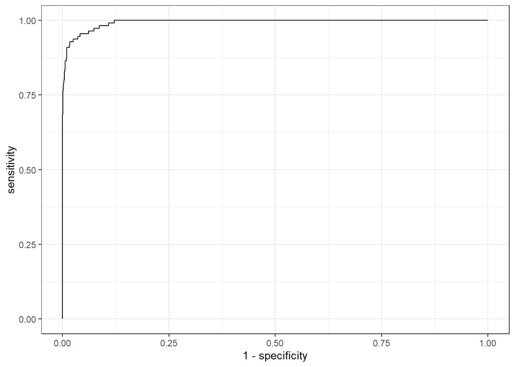

```r
knn_test_predictions_prob <- fit_knn |>
  predict(typing_test,
          type = c("prob")) |>
  cbind(typing_test$y) |>
  mutate(y = typing_test$y)

knn_roc <- knn_test_predictions_prob |>
  roc_curve(truth = y,
            `.pred_1`,
            event_level = "second")

knn_roc |>
  ggplot(aes(x = 1 - specificity, y = sensitivity)) +
  geom_path()
```

Does it outperform a random forest fit to the same training data?

```r
library(ranger)
rf_parsnip <- rand_forest() |>
  set_mode("classification") |>
  set_engine("ranger")

rf_workflow <- workflow() |>
  add_model(rf_parsnip) |>
  add_formula(y ~ .) |>
  step_normalize(all_predictors())

fit_rf <- rf_workflow |>
  fit(typing_train)

fit_rf |>
  extract_fit_engine()
```

```
## Ranger result
##
## Call:
##  ranger::ranger(x = maybe_data_frame(x), y = y, num.threads = 1,      verbose = FALSE, seed = sample.int(10^5, 1), probability = TRUE)
##
## Type:                             Probability estimation
## Number of trees:                  500
## Sample size:                      4800
## Number of independent variables:  32
## Mtry:                             5
## Target node size:                 10
## Variable importance mode:         none
## Splitrule:                        gini
## OOB prediction error (Brier s.):  0.01315127
```

```r
rf_test_predictions <- fit_rf |>
  predict(typing_test) |>
  cbind(typing_test$y) |>
  mutate(y = typing_test$y)

rf_test_predictions |>
  conf_mat(truth = y, estimate = .pred_class)
```

```
##           Truth
## Prediction    0    1
##          0 1489   35
##          1    0   76
```

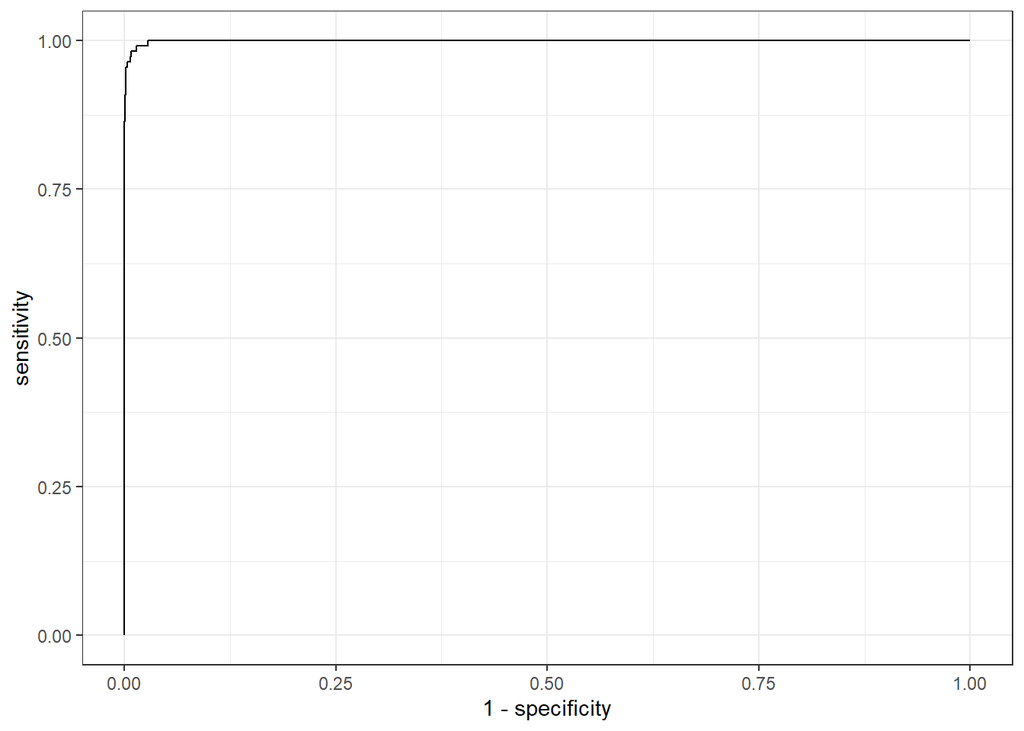

```r
rf_test_predictions_prob <- fit_rf |>
  predict(typing_test,
          type = c("prob")) |>
  cbind(typing_test$y) |>
  mutate(y = typing_test$y)

rf_roc <- rf_test_predictions_prob |>
  roc_curve(truth = y,
            `.pred_1`,
            event_level = "second")

rf_roc |>
  ggplot(aes(x = 1 - specificity, y = sensitivity)) +
  geom_path()
```

Though the confusion matrix shows that the KNN model might be a more accurate classifier, the ROC curve shows that the random forest model makes better probabilistic predictions.